# Truthiness Model Specification

Susan VanderPlas

July 25, 2018

# 1 Introduction

## 1.1 Definitions

- *subject relatedness*: The image shown is related to the subject of the claim (e.g. the country or geographic entity)
- *topic relatedness*: The image is related to the topic of the claim (e.g. the numerical dimension of the claim)
- *spatial-only claim*: The claim can be evaluated using only a map without any additional explicit variables (e.g. the claim deals with explicit geographic boundaries)
- *probative value*: The image shown can be used to determine whether the claim is true or false
  - *pictures* do not provide any probative value
  - *charts* may provide probative value if they are both subject and topic related [1]
  - *maps* may provide probative value if they are both subject and topic related, but they are not guaranteed to provide probative information even if both subject and topic relatedness are met.

[1] In the current specification, there is no provision for subject-related, topic-related nonprobative charts. It is not completely impossible to imagine that such charts might exist, however.

## 1.2 Notation

Let:

- $\alpha_i$, $i = 1, 2, 3$ correspond to image type (1 = picture, 2 = chart, 3 = map)
- $\beta_j$, $j = 1, 2$ correspond to relatedness type (1 = subject, 2 = topic)
- $\gamma$ correspond to probative value
- $\delta_k$, $k = 1, 2$ correspond to claim type (1 = spatial-only, 2 = data)
- $\zeta_l$, $l = 1, 2$ correspond to claim truth (1 = true, 2 = false)
- $\eta_m$, $m = 1, ..., 12$ correspond to claim number (3 replicates of each combination of claim truth and claim type)
- $\rho_n$, $n = 1, ...$ correspond to participant number

$\delta$, $\zeta$, and $\eta$ can be collapsed into a single random effect $\eta$ for simplicity if it is not deemed important to know the effect of the actual truth of the claim.

Fixed/Random Effects:

- $\alpha$ fixed
- $\beta$ fixed
- $\gamma$ fixed
- $\delta$ fixed
- $\zeta$ fixed
- $\eta$ random
- $\rho$ random

# 2 Trials

The following images are generated for each of 12 claims. Of the claims, 6 are spatial only (can be determined from a map without any additional variables), 6 require additional data. Within spatial classification, half of the claims are true, and half are false.

[output not shown]

# 3 Experiment Setup

## 3.1 Participant Instructions

You will be shown a sequence of twelve claims that may or may not be accompanied by an image. You will have approximately 45 seconds to read each claim and evaluate whether it is true or false. If you do not know the answer, give your best guess.

# 4 Truthiness Models

The specification of effects for $\delta, \zeta, \eta, \rho$ are constant throughout the models discussed in this section and have been omitted for simplicity.

## 4.1 Vanilla Truthiness

The standard truthiness paradigm compares claim evaluations made in the presence of a related or unrelated photo.

Trials: 0, 1, 2

$$\text{logit}(\text{True Claim}) \propto \alpha_1 + \beta_1 1_{subj. related}$$

### 4.1.1 Simulation

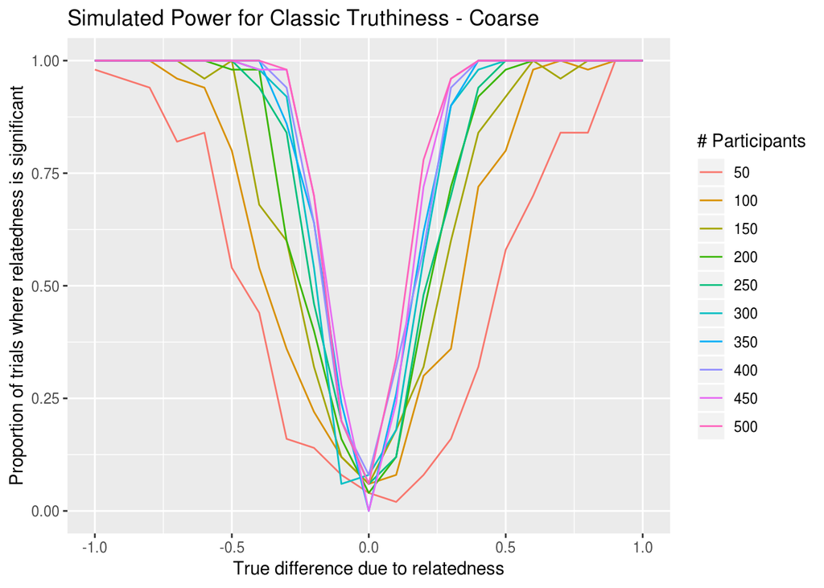

## 4.2 Chart Truthiness

The chart truthiness paradigm compares claim evaluations made in the presence of a subject related or topic related nonprobative chart.

Trials: 0, 3, 4, 6

Trials: 0, 7, 8, 9, 10

$$\text{logit}(\text{True Claim}) \propto \alpha_3 + \beta_1 1_{subj. related} \times \beta_2 1_{topic\ related}$$

## 4.3 Item-Type Truthiness

This model examines only the effect of subject-relatedness and does not consider topic-relatedness, as it is not feasible to get pictures which are topic-related.

Trials: 0, 1, 3, 7, 2, 4, 8

$$\text{logit}(\text{True Claim}) \propto \alpha * \beta_1 1_{subj. related}$$

This model fully contains the Vanilla truthiness model, but does not contain the chart/map truthiness models because of the exclusion of the topic-related effects.

## 4.4 Item Type Motivation

This model examines whether having probative images increases the probability of a claim being evaluated as true. That is, does the participant bother using the information they’re given to evaluate the claim? If not, then we have fairly big problems…

Trials: 0, 3, 4, 5, 6, 7, 8, 9, 10, 11

$$\text{logit}(\text{True Claim}) \propto \alpha_{2,3} \times (\beta_1 1_{subj. related} \times \beta_2 1_{topic\ related} + \gamma 1_{probative})$$

## 4.5 Simplified Truthiness and Motivation

This model combines truthiness and motivation exploration.

Trials: 0, 4, 3, 5, 8, 9, 11

$$\begin{align}\text{logit}(\text{True Claim}) \propto & \phantom{ + }\delta\times 1_{spatial-only} + \zeta \times 1_{true\ claim} & \text{claim fixed effects}\\
&+ \alpha_2\times 1_{chart} + \alpha_3 \times 1_{map} + \beta \times 1_{related} + \gamma \times 1_{probative} & \text{image fixed effects}\\
&+ \eta_m + \rho_n & \text{random effects for claim and participant}\\
& + \epsilon_{tmn} & \text{random effect for evaluation of specific claim}\end{align}$$

### 4.5.1 Simulation

Simulation setup:

- 50 simulation reps per parameter combination
- Trials allocated to participants as follows:
  - Each participant sees each claim once
  - Each participant gets image-free claims twice (2)
  - Each participant gets each chart claim once (6)
  - The remaining 4 trials are randomly chosen from the picture conditions
- Claim-specific effect randomly distributed $\sim N(0, 3)$ (that is, values generated on logit scale)
- True effect size for truthiness generated on logit scale between -1 and 1
- Bernoulli trial conducted for each participant/trial combination to select an answer according to the data-generating model

Model: - Simplified model to reduce simulation time - only manipulate truthiness, hold probative effect constant at 0  
The power calculations for truthiness hold for probative effect as well - `glmer` model statement: `claim_eval ~ (1|claim) + chart + related + probative + (1|participant)` - random effects for claim and participant - fixed effects for chart, truthiness, and probative value

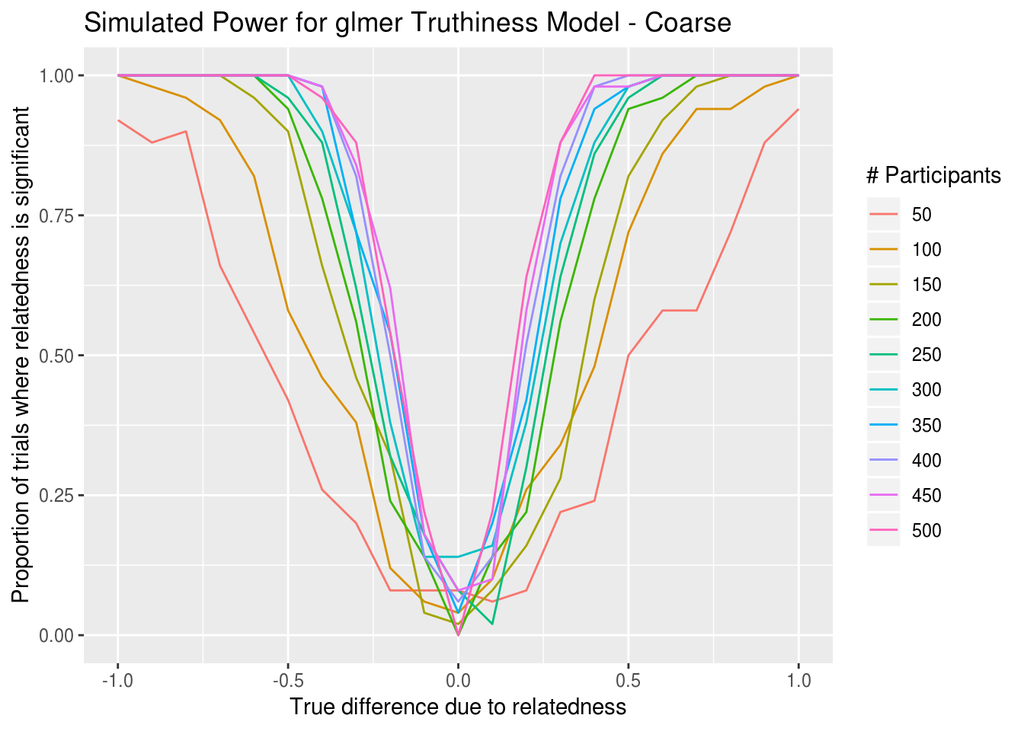

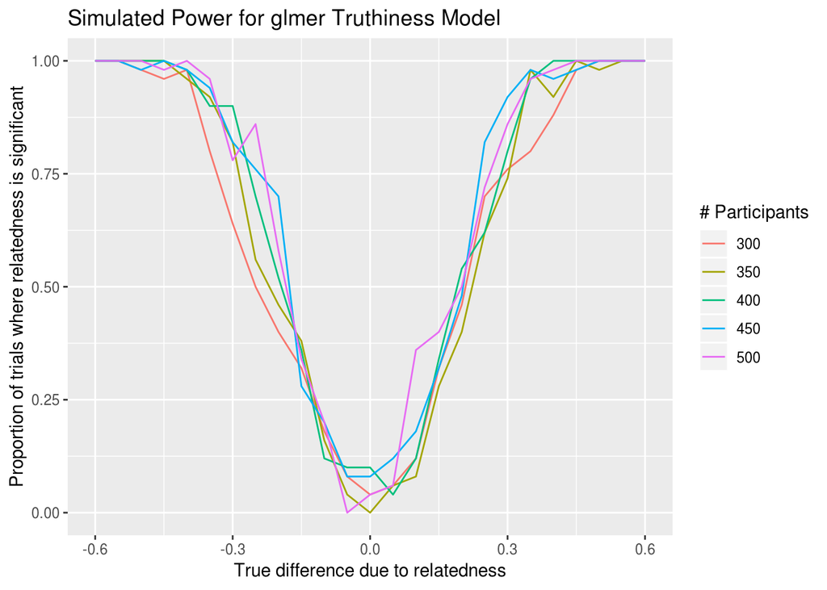

Conclusion: need ~350 participants to have a 75% chance of detecting a difference of 0.3 on log-odds scale. Additional participants don’t actually help that much.